# Presentazione del progetto

## Liu Weijie, 166854

## 2023/24

### Dataset utilizzati:

#### https://www.kaggle.com/datasets/karlorusovan/league-of-legends-soloq-matches-at-10-minutes-2024

#### https://www.kaggle.com/datasets/jakejoeanderson/league-of-legends-diamond-matches-ff15

### **League of Legends** è un gioco MOBA 5v5 con l'obiettivo finale di distruggere il nexus (base) avversario.

### Nel gioco esiste una meccanica chiamata *"forfeit"*, ovvero rinunciare o arrendersi al minuto 15, che può essere approvata insieme con altri 3 giocatori

## Ha ancora senso la partita che sto giocando al minuto 15❓

### Se si, su quali aspetti devo ancora migliorare per vincere la partita?🤨

### Se no, ha senso continuare a giocare oppure arrendersi?

#### **Uccisioni**: Quando sconfiggi l'avversario, il numero dell'uccisione aumenta; e verrai incentivato con l'oro

#### **Minion**: Soldatini che muovono tra le corsie, se uccidi i minion ti danno oro

#### **Oro**: Per comprare gli oggetti che potenziano il giocatore

#### **Torre**: Per raggiungere al nexus nemico ci sono 3 torri su ogni corsia, si impiega molto tempo per distruggere la torre

#### **Placca**: Scudi che prottegge solo la prima torre, c'è ne sono 5 per ogni torre per tutte 3 corsie, ad distruzione delle placche verrai ricompensato dell'oro.

#### **Primo Sangue**: La squadra che ottiene la prima uccisione del gioco, la squadra verrà ricompesato di un piccolo somma di denaro

#### **Draghi**: Mostri neutri, se uccisi darà alla squadra piccoli potenziamenti, ne sono presenti diversi tipi che danno potenziamenti diversi

#### **Grubs**: Mostri neutri, si generano 3 per volta per 2 volte (6 totali), se sconfitti aiuteranno ai giocatori di distruggere più velocemente le torri

## Analisi della correlazione dei dati

#### A parte le correlazioni ovvie, sono presenti dati che hanno dei legami deboli, per esempio placche della squadra blu è correlata positivamente alle torri della sqaudra rossa

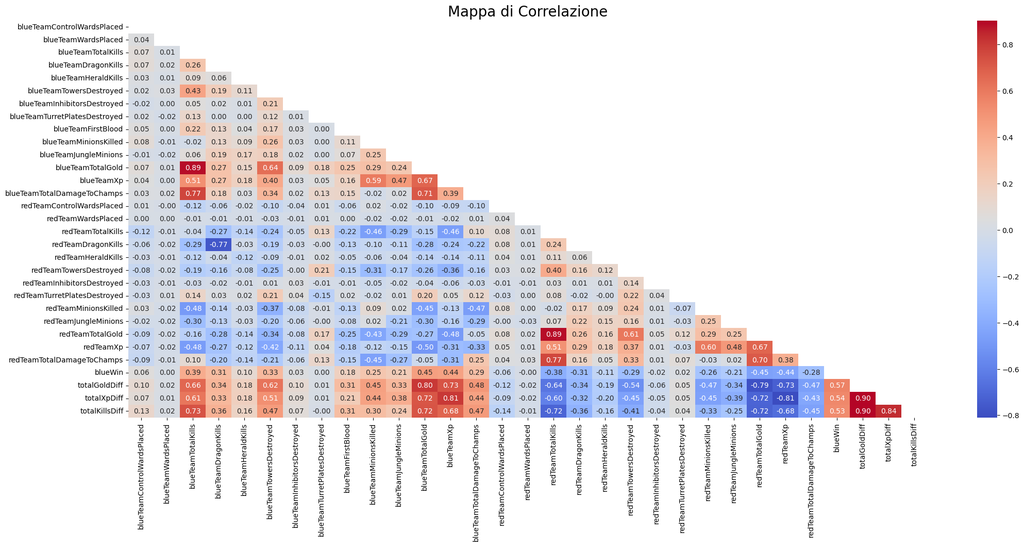

## Quanti uccisioni sono necessarie per vincere i primi 15 minuti?

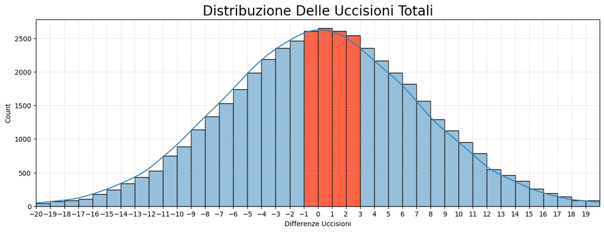

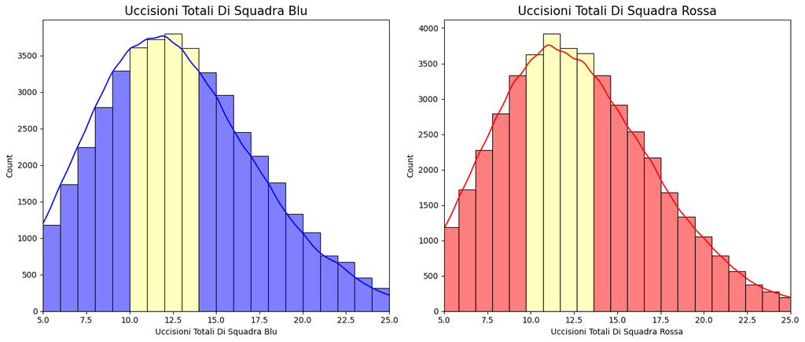

#### più di 35% delle partite terminano con le squadre aventi tra 10 / 13 uccisioni

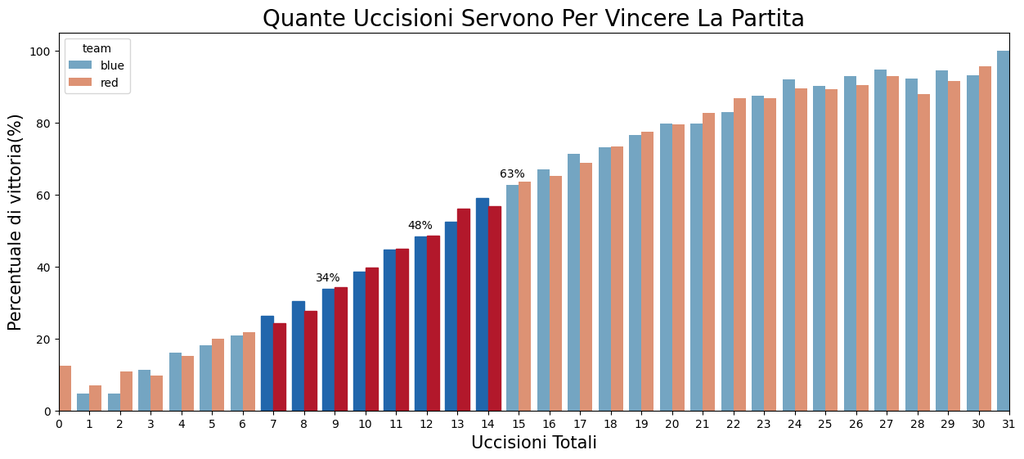

### Il mistero che la squadra blu vincono più dei rossi

#### Negli anni passati, tanti giocatori segnalano che la squadra blu vince più della rossa

#### I dati ufficiali del gioco nel 2017 segnala che la squadra blu vince 52.6% delle partite

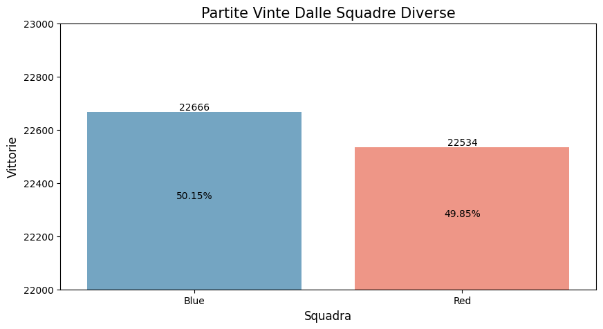

## Rapporto Placche Torri

#### Quando la squadra blu distrugge più di 6 placche, la squadra rossa inizia a distruggere più torri blu

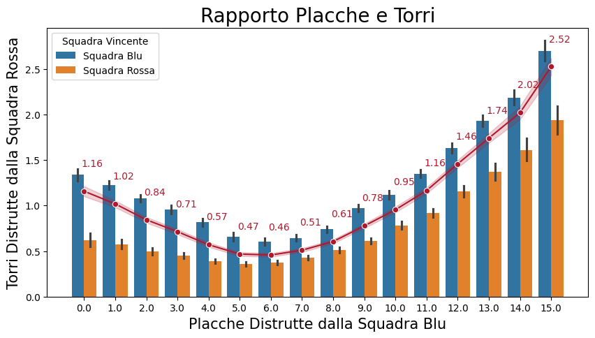

### Importanza del Primo Sangue

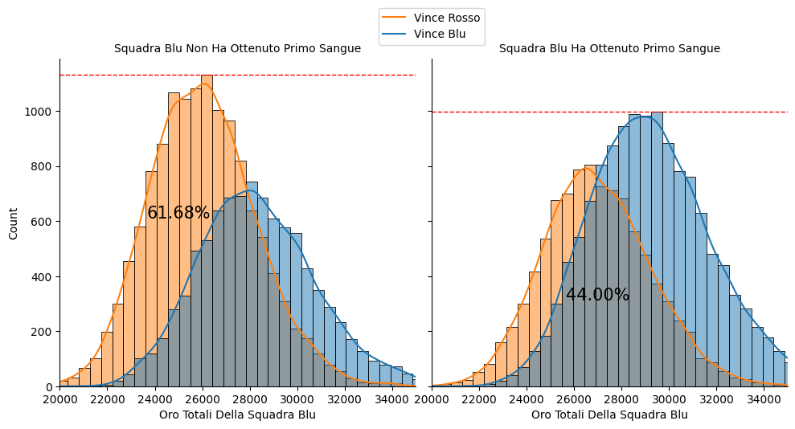

#### La squadra blu ottine circa 3000 gold in più se ottine il primo sangue, di conseguenza aumenta anche la probabilità di vittoria

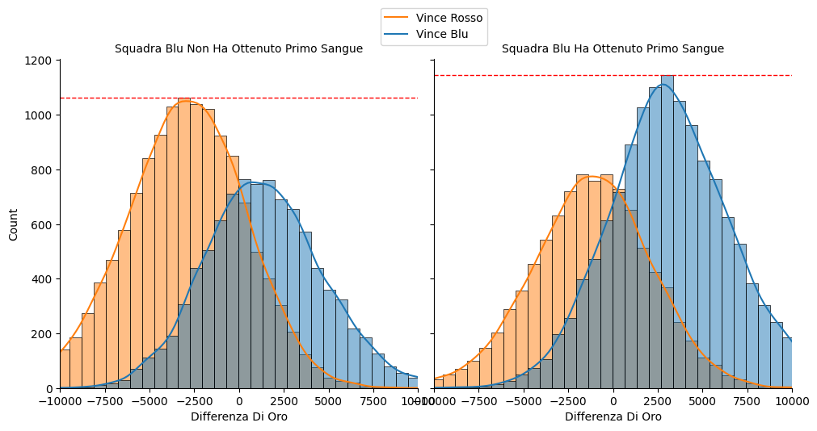

#### La differenza di Oro è di 600 per la squadra che ottiene il primo sangue

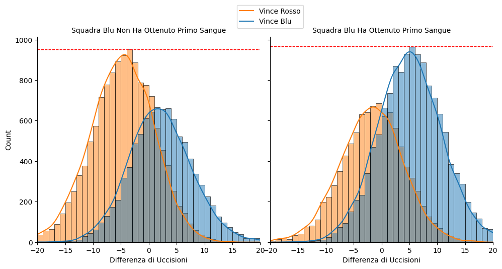

#### Differiscono di 3 uccisioni nei casi dell'ottenimento del primo sangue

### Quanto è importante ottenere i potenziamenti dei monstri neutri

#### A parità della quantità dei draghi la squadra rossa ha meno percentuale di vittoria

#### La squadra rossa è di 3.8% sotto della squadra blu, ogni drago aumenta di 20% la percentuale di vittoria

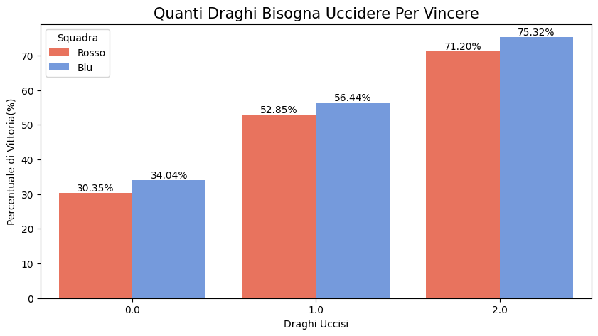

### Quale tipologia di drago porta la vittoria alla squadra nei primi 15 minuti

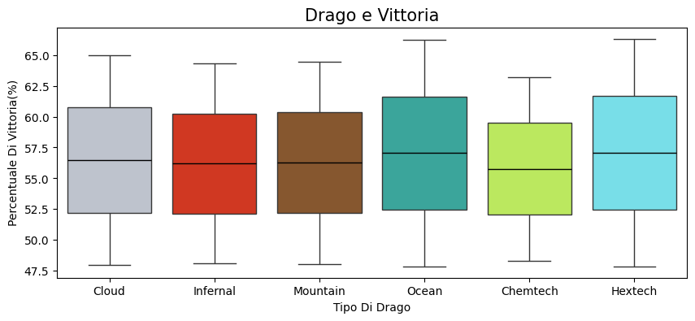

#### I draghi Hextech e Ocean presentano una percentuale di vittoria più alta rispetto ad altri draghi, ambe due 66.3% di vittoria; mentre il drago Chemtech la più bassa con 63.2%

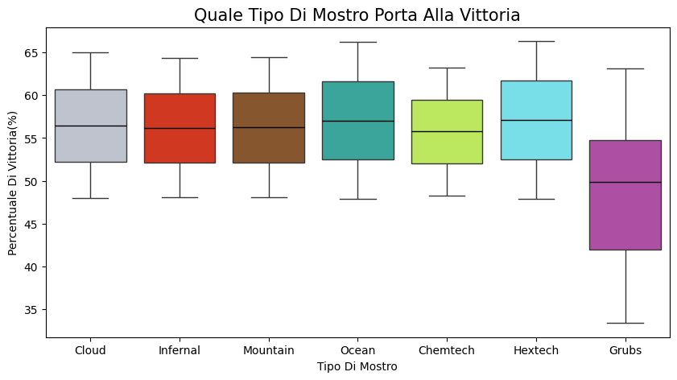

#### Se aggiungiamo anche i grubs nella lista si nota che uccidendo 1 grub si avrà solo 33.3% di vittoria, se vengono uccisi 6 grubs si avrà 63.1% di vittoria, quasi la stessa percentuale di vittoria uccidendo un drago Chemtech

### Conclusioni

#### La percentuale di vittoria della squadra **blu è di 50.15% e la rossa 49.85%**, differiscono solo di **0.30%**, rispetto agli anni precedenti è più bilanciata la vittoria tra le due squadre

#### Se distruggi più di **6 placche**, rischi che la squadra avversia inizii a distruggere più torri, diminuendo la percentuale di vittoria

#### Il **primo sangue** è un fattore importante per vincere la partita, dato che influenza l'oro e le uccisioni della squadra, che sono i fattori più importanti per la partita

#### A parità di draghi la **squadra rossa perde più facilmente** rispetto alla squadra blu, l'uccisione del drago influenza pesantemente la partita

#### La squadra che ha ottenuto i poteri del drago **Hextech e Ocean** hanno **più probabilità di vincere**

#### **I draghi hanno priorità maggiore dei grubs**, che se uccisi tutti 6 equivale ad uccidere un drago Chemtech